# Ranking by Engagement

Tom Cunningham, May 8 2023.[^1]

<sup>1</sup> tom.cunningham@gmail, [@testingham](https://twitter.com/testingham). I worked at FB for 5 years, and Twitter for 1 year, now affiliated with the [Integrity Institute](https://integrityinstitute.org). This note entirely based on public information. Thanks to comments from Jeff Allen, Jacquelyn Zehner, David Evan Harris, Jonathan Stray, and others.

**Six observations on ranking by engagement:**

1. **Internet platforms rank content primarily by the predicted probability of engagement.** Platforms show each user the items that are most likely to make the user click, or reply, or retweet, etc.[^2]
2. **Platforms rank by engagement because it increases user retention.** In experiments which compare engagement-ranked feeds to unranked feeds (“chronological” feeds) the users with engagement-ranked feeds consistently show substantially higher long-run retention (DAU) and time-spent. Platforms care about engagement not in itself but as a means to an end, and when faced with a tradeoff between engagement and retention would choose retention.
3. **Engagement is negatively related to quality.** The content with the highest predicted engagement very often has low scores by various measures of objective quality: clickbait, spam, scams, misleading headlines, copied content, inauthentic content, and misinformation. Intuitively this is because engagement only measures immediate appeal, and the most appealing content can be the most disappointing. Low quality content typically *hurts* retention, and as a consequence platforms often supplement their engagement-based ranking algorithms with a range of proxies for content quality.
4. **Sensitive content is often both engaging and retentive.** Engagement-ranked feeds often increase the prevalence of various types of “sensitive” content: nudity, bad language, abuse, hate speech, hyper-partisan politics, etc.. However unlike low-quality content, reducing the prevalence of sensitive content often hurts retention, implying sensitivity is positively correlated with retention.
5. **Sensitive content is often preferred by users.** Platforms have tried out many experiments with asking users directly for their preferences over content. The results have been mixed, and platforms have often been disappointed to find that users express fairly positive attitudes towards content that the platform considers sensitive.
6. **Platforms don’t want sensitive content but don’t want to be seen to be removing it.** Platform decision-makers often have principled reasons for limiting the distribution of certain types of sensitive content. Additionally there are instrumental reasons: sensitive content attracts negative attention from the media, advertisers, app stores, politicians, regulators, and investors. But platforms are also liable to get negative attention if they make substantive judgments about the sensitivity of content, especially when it has some political dimension. As a consequence platforms often target sensitive content indirectly by using proxies, and they prefer to justify their decision-making by appealing to user preferences or to user retention.

<sup>2</sup> In this note I’m using “engagement” to refer to individual actions not user-level metrics like time-spent or DAU.

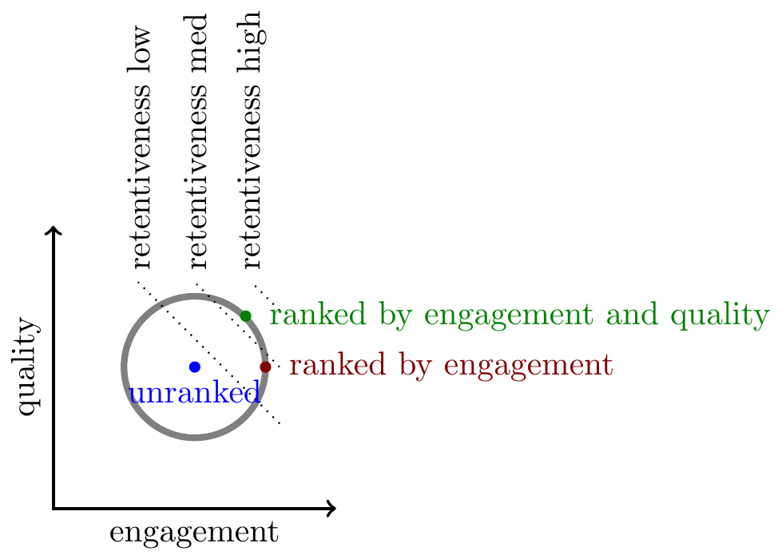

**In an appendix I formalize the argument.** I show that all these observations can be expressed as covariances between different properties of content, e.g. between the retentiveness, predicted engagement rates, and other measures of content quality. From those covariances we can derive Pareto frontiers and visualize how platforms are trading-off between different outcomes.

# Argument in Detail

1. **Talking about ranking is complicated.** To help simplify things I bucket attributes of content into five types:
   1. **Engagement:** the predicted probability of a user clicking, commenting, retweeting, etc., on a specific piece of content.
   2. **Retentiveness:** the causal contribution of seeing the content on a specific user’s long-term retention (e.g. DAU). Unlike the other attributes this can never be directly observed, only inferred from experiments.
   3. **Quality:** some objective measure of quality, e.g. whether fact-checked, whether the headline is misleading, whether the linked website has a high ad-load, whether the source is trustworthy, etc..
   4. **Sensitivity:** whether the content could be offensive, harmful, corrosive – e.g. nudity, bad language, abuse, hate speech.
   5. **Preference:** the user’s response to a survey question, e.g. “do you want to see more of this type of content?”

   Note that “quality” and “sensitivity” apply to pieces of content, while the other three attributes apply to relationship between a user and a piece of content.
2. **Social media platforms rank their content primarily by predicted engagement.** The core ranking model for most social platforms is a weighted average of predicted engagement rates.[^3]

   However ranking functions also include hundreds of other tweaks incorporating non-engagement features, upranking or downranking content depending on, for example, the media type (photo/text/video), the relationship between the user and the author (whether you follow this person), various predictions of of objective quality (classifiers predicting whether the content is spam, offensive, adult, misinformation, etc.), or other features (network centrality, off-platform popularity, etc.). They also often have some diversity rules to prevent the content that is shown from being too similar.[^4]

   Ranking by popularity is common for other media: we look at lists of bestsellers, most popular, highest grossing, most watched, or top charting. Attention is limited and it would be inefficient to offer people a random selection of everything that’s available.
3. **Predicted engagement rates are mostly historical engagement rates.** In many cases the most important predictors of whether a user will engage with a piece of content are (1) this user’s historical rate of engagement on similar pieces of content (e.g. content from the same author, or of the same media-type); (2) other users’ rate of engagement on this piece of content. Platforms do use more complicated models (embeddings and neural nets), those models typically are most valuable for qualitatively new types of content, when you have relatively sparse historical data either on the user or on the item.
4. **Platforms care primarily about long-run retention, engagement is a means to that end.** The outcome that leadership care about the most is long-run retention, measured with metrics like Daily Active Users (DAU).[^5] They would generally sacrifice substantial amounts of engagement in return for DAU. They also would sacrifice substantial short-term DAU if it could be shown with confidence that it would lead to higher long-term DAU.

   This point is often unclear because many changes to ranking (as measured in experiments) move engagement and retention in the same direction, and move short-run and long-run metrics in the same direction, meaning that we cannot easily tell which metric is decisive. Individual teams are often given targets to increase short-term engagement but that is mainly because that metric is easier to measure.
5. **Engagement-ranked feeds have substantially higher long-term retention and time-spent than chronologically-ranked feeds.** Users who are given engagement-ranked feeds in experiments typically have higher long-term DAU by single-digit percentages (1%-9%), and higher long-term time-spent by double-digit percentages (10%-99%). Accounting for network effects makes the aggregate difference even larger.[^6]
6. **Engaging content is often low quality.** Despite the positive relationship between engagement and retention, many studies have found that highly-engaging content is has lower-than-average quality:
   - **In summer 2016 half of Facebook’s most-seen posts related to the US election were misinformation.** As [reported](https://www.buzzfeednews.com/article/craigsilverman/viral-fake-election-news-outperformed-real-news-on-facebook) by Craig Silverman at Buzzfeed. This exceeds the *average* rate of misinformation, i.e. most-engaging posts have much lower than average quality.
   - **Facebook’s top group and pages were run by troll farms in 2019.** A series of internal analyses by by Jeff Allen ([subsequently leaked](https://s3.documentcloud.org/documents/21063547/oct-2019-facebook-troll-farms-report.pdf)) found that a substantial share of Facebook’s top pages, groups, and posts, were run by “troll farms,” whose main tactic was reposting copied content that had high engagement rates.
   - **On Facebook high-quality content received lower engagement.** In the late 2010s Facebook maintained an internal “quality” score for content (FUSS=“Feed Unified Scoring System”). A data scientist’s analysis from 2019 ([subsequently leaked, see p.10](https://s3.documentcloud.org/documents/21063547/oct-2019-facebook-troll-farms-report.pdf)) found that low-quality content had significantly higher predicted engagement rates.[^7]
   - **Facebook’s most-viewed posts remain very low quality.** Since early 2021 FB has been releasing a dataset of their 20 most-viewed links and posts. An [Integrity Institute analysis](https://lookerstudio.google.com/u/0/reporting/28bc32fd-a067-4b4a-9be0-637e8c9bd917/page/0Z3mC?s=g7_EWEyFjrc) by Jeff Allen has found that each quarter 60-80% of the posts fail some basic checks, either “the account behind it is anonymous, is posting unoriginal content, using spammy page or group networks, or if the post or link violated Facebook’s community standards.”
   - **Twitter’s ranking has mixed effects on political content.** Huszar et al. (2021) compare political content of users who are randomized to ranked vs chronological feeds. They report (1) for political parties, ranked feed tends to amplify the right-wing parties somewhat more than left-wing parties (but the same does not hold for individual politicians); (2) for US media sources, ranked feed amplifies “sources that are more partisan compared to ones rated as center”.[^8]
7. **Many platforms have found that increasing quality helps retention.** Platforms have tried to address quality problems by defining measures of objective quality:
   - **Facebook uses many heuristics and classifiers to identify various types of low-quality content:** Facebook identifies and downranks, among other things, engagement bait, links that go to ad-farms, scraped content, titles that withhold information, and titles that exaggerate information. In each case these types of content would generate high engagement but give users a bad experience, and in most cases experiments confirmed that dowranking these types of content increases long-run user retention.
   - **Facebook uses some metadata features to identify low-quality content.** E.g. Facebook calculates the [“click gap”](https://www.cnbc.com/2019/04/10/facebook-click-gap-google-like-approach-to-stop-fake-news-going-viral.html) (the amount of organic traffic a website gets) and [“broad trust”](https://www.wired.com/story/how-facebook-wants-to-improve-the-quality-of-your-news-feed/) (diversity of engagement across users).
   - **YouTube has introduced a series of quality adjustments to ranking:** e.g. downranking [“sensationalistic tabloid content”](https://blog.youtube/inside-youtube/on-youtubes-recommendation-system/) and upranking [“authoritative content”](https://blog.youtube/inside-youtube/on-youtubes-recommendation-system/).

   Some companies have also shifted engagement weights to put relatively more weight on “deeper” measures of engagement:
   - **In 2012 YouTube switched from maximizing clicks to maximizing watch-time.** They found it led to a short-term decrease in clicks but a long-term [increase in retention](https://blog.youtube/inside-youtube/on-youtubes-recommendation-system/). I believe Netflix similarly has invested a lot of time in developing “deep” measures of engagement.
8. **Engagement measures *immediate* quality, and hence is a poor proxy for the quality of factual claims.** Engagement necessarily measures the immediate reaction of a user to a piece of content, and thus ranking by predicted engagement will surface content that *appears* to be good. This is fine when there is no hidden aspect to quality, e.g. for jokes and pictures which mostly be judged in the moment. However if we rank informational content by predicted engagement it will tend to surface the claims that are the most sensational or intriguing independent of whether they are true.

   If apples were sold only by how they looked, and not by how they tasted, then we would be offered delicious-looking and bland-tasting apples.

   I believe this basic mechanism explains why internet platforms typically have higher rates of exaggerated, misleading, or false content compared to traditional media (newspapers, television, etc.). Traditional media do not publish whichever headlines would maximize short-run sales because that would harm long-run sales. This also explains why platforms have found that they can substantially improve retention by building proxies for quality.
9. **A negative relationship between engagement and quality can be caused by unscrupulous publishers.** Suppose each publisher can produce a fixed number of headlines, which will vary in (1) the headline’s propensity to be clicked, and (2) whether the headline is true. There are two types of publishers:
   1. Honest publishers: they choose the most-engaging headlines from within the subset that are true.
   2. Dishonest publishers: they choose the most-engaging headlines from the universe of all possible headlines (irrespective of truth).

   In this world the most-engaging headlines will be disproportionately false compared to the average headline. In the long run consumers will learn some skepticism, and to discount headlines in proportion to how clickable they seem, but they are unlikely to learn to discriminate perfectly. There’s always a chance that an intriguing headline will be true, and so the negative correlation would persist in equilibrium.[^9]
10. **Platforms have been slow in improving the quality of ranked content.** I discuss above some examples of Facebook’s slowness in addressing problems with the quality of content. I think this slowness is for two mains reasons. First, predicting engagement is a well-defined technical problem with a track record of success while evaluating content-quality is much more open-ended and difficult to validate. Hard-headed engineers often argue that a user’s preferences are revealed in their engagement and that evaluating quality is paternalistic. Secondly, platforms are nervous of being opinionated about objective quality because they don’t wish to take sides on politically delicate issues. In 2016 Facebook was criticized for using human judgment in determining what topics are “trending”, and in the wake of that criticism many projects which involved human judgment were shut down and replaced with automatic systems. Then in 2020 engineers on News Feed were told to avoid using words such as “trust” or “quality” or “authority”, and to instead use language that referred only to user preferences.
11. **Sensitive content is often both engaging and retentive.** I have defined “sensitive” content to include nudity, bad language, abuse, hate speech, hyper-partisan politics, etc.. Sensitive content often has higher-than-average engagement rates, and when content is demoted this often hurts retention, implying that sensitivity is positively correlated with retentiveness.
    - A 2023 academic study by [Beknazar-Yuzbashev et al.](https://drive.google.com/file/d/1HYiBOGLNM91RBiqBlxKFvjDhJAuCxe60/view) found that filtering the 7% most-toxic content on Facebook reduced overall Facebook content consumed by 20%.
12. **Platforms don’t want to show sensitive content.** Platforms are clearly prepared to pay a cost to reduce the prevalence of sensitive content, both in terms of retentiveness (DAU), and in the monetary cost of engineers, labelers, and computation.[^10]

    The platforms have many reasons for avoiding sensitive content, independent of its effect on retention, but internally there is often an ambiguity about the contribution of different reasons. In part decisions are driven by a feeling of moral duty to not amplify content that is harmful. However there are also many instrumental reasons, because sensitive content often causes friction with advertisers, app stores, regulators, media, employees and investors.

    Misinformation is a somewhat special case. From what has been discussed before, misinformation can be expected to reduce retention because it’s not true. However misinformation is very often related to sensitive issues, e.g. partisan politics, race relations, vaccines, and often reports falsehoods that support the viewer’s political prejudices.
13. **Platforms avoid directly penalizing sensitive content.** Platforms are caught in a double bind: there are strong pressures to reduce the amount of sensitive content on their platform, but there is also a pressure not to be seen to be making judgments about the objective value or harm of content. They want a garden with no weeds but they also wish to have clean hands. This often causes a bifurcation between the nominal reason for a policy and the real reason. Some examples:
    - **Platforms often downrank engagement patterns because they correlate with sensitive content.** It is common to downrank posts which features a specific engagement pattern (e.g. certain types of sharing, certain types of downstream attributes), and the downranking is justified internally based on the correlation with measures of quality or sensitivity, e.g. misinformation, or hate speech, or hyperpartisan content. This is odd because it would seem to be more efficient to target the sensitive content directly, i.e. instead of downranking the proxy, use the proxy as a feature in a classifier, and downrank based on the classifier output. However platforms avoid this approach in part because they are nervous about the perception of being perceiving as judges of the quality of content.
    - **Platforms speak about sensitivity rules as if they were adopted to serve the interests of their users.** Google’s Jigsaw group has an influential set of definitions of content quality, their [definition](https://support.perspectiveapi.com/s/about-the-api-attributes-and-languages?language=en_US) of a “toxic” comment is *“a rude, disrespectful, or unreasonable comment that is likely to make people leave a discussion.”* This definition is worded to presuppose that rude comments cause lower retention. The definition thus allows a platform to talk about their toxicity classifiers as if they were solely serving the interests of the users exposed to toxic language.
    - **Survey questions are chosen based on their correlation with measures of sensitive content.** Platforms will often try out multiple different wordings of a survey question and decide which one to use by comparing the results with their internal measures of content quality and sensitivity, leading to survey questions that are somewhat awkwardly worded (e.g. asking people “is this good for the world?”).
14. **Subjective user ratings of quality have a mixed relationship with objective measures of quality.** Platforms have often tried to collect explicit user feedback about quality, e.g. asking “was this worth your time?”, “do you want to see more of this?”, “was this informative?”. In my experience, for most such questions, responses are highly correlated with engagement, but often show a negative correlation with objective measures of quality. E.g. people often rate misinformation as “informative” and “worth my time.”

    Nevertheless some of these initiatives have had success in raising both objective quality and retention, e.g. Facebook recently launched a prompt asking “would you like to see more posts like this?” The signal from this prompt apparently increases both retention and many objective measures of quality.
15. **Platforms additionally care about engagement because of network effects.** I said above that platforms care about engagement primarily insofar as it’s a proxy for retention, however there is an additional reason to pay attention to engagement. When one user engages (likes, comments, retweets) this increases the value of the platform to all the other users, and so has an indirect positive effect on retention. For this reason platforms are generally willing to sacrifice some retention in return for engagement, as measured in an experiment, if the sacrifice is sufficiently small.

<sup>3</sup> I believe this is true for almost all platforms with personalized recommendations including YouTube, Netflix, and Amazon.

<sup>4</sup> For simplicity the rest of the discussion treats the causal effect of content as purely separable.

<sup>5</sup> Most publicly-traded platforms report in their quarterly earnings just one non-financial metric: the number of active users (DAU/MAU/mDAU, etc.). I do not know of any company that publicly reports a metric of aggregate engagement.

<sup>6</sup> Huszar et al. (2021) note that since Twitter introduced a ranked timeline in 2016 they maintained a 1% of users with a chronological feed.

<sup>7</sup> These correlations can be difficult to interpret: suppose there is no correlation between engagement and quality in the pool of all available content, there will nevertheless be a negative correlation among the subset of content that is *seen* if the ranking algorithm penalizes low-quality content, meaning low-engagement low-quality content will never be shown to users.

<sup>8</sup> Bakshy et al. (2015) found that Facebook’s feed-ranking doesn’t substantially change the share of cross-cutting (across-the-aisle) content seen.

<sup>9</sup> A more formal version: each consumer sees a single headline with observed signal $s$ and chooses whether to click. The payoff from clicking is $s$ if it’s from an honest publisher, zero otherwise, and there’s some stochastic outside option so the consumer’s probability of clicking is continuously increasing in the expected payoff from clicking. Honest publishers report their signals drawn from $f_H(s)$, dishonest publishers choose any signal. In equilibrium the dishonest publishers’ signal distribution, $f_D(s)$, must be such that all signals with non-zero mass have have an equal click-through rate, meaning there is some $\kappa$ such that for every $s>\kappa$, $f_D(s)=\frac{s-\kappa}{\kappa}f_H(s)$. Thus low click-through-rate headlines ($s<\kappa$) are all true, but high click-through rate headlines ($s>\kappa$) all have some share which are false. Qualitatively: if a headline is not very interesting, then you believe it; but if it’s interesting then you discount exactly inversely to how interesting it is. In this model we have (1) retentiveness (consumer surplus) is increasing with engagement; (2) quality (truth) is decreasing with engagement; (3) retentiveness (consumer surplus) would be higher if you rank by both engagement and quality (e.g. by removing false stories).

<sup>10</sup> Platforms often spend around 5% of their total costs on content moderation, despite the prevalence of sensitive content and the effects on retention typically being closer to 0.1% or less.

# Technical Appendix: Expressed as a Covariance Matrix

**We can express most of the argument above with a covariance matrix.** Given a user we can give scores to each piece of content with respect to the five attributes defined above. Then we can give a reasonable characterization of the platform ranking problem with the following covariance matrix:

[output not shown]

**Given this covariance matrix, we can draw Pareto frontiers and indifference curves.** Each Pareto frontier represents the set of achievable tradeoffs between two outcomes. I explain below how elliptical Pareto frontiers and linear indifference curves can be derived from the covariance matrix if we assume that everything is distributed joint Normally.

**Retentiveness and engagement.** We can draw a Pareto frontier between retention and engagement as below. We do not directly observe the retentiveness of content, but we know that ranking content by engagement (i.e. choosing the farthest right-hand point on the Pareto frontier) increases retention relative to an unranked feed, so we can infer that retentiveness and engagement are positively correlated, thus the Pareto ellipse must be upward-sloping.

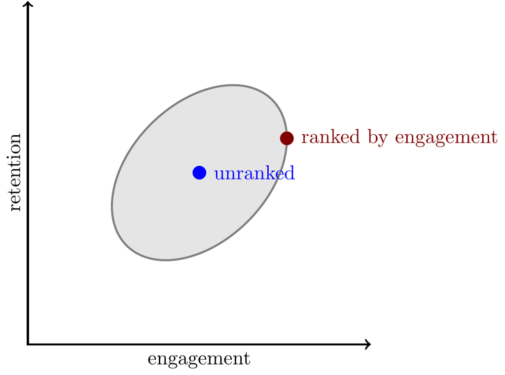

**Engagement and quality.** As discussed above, we often see that (1) measures of content quality have zero or negative correlation with engagement, (2) downranking low-quality content (equivalently, upranking high-quality content) increases retention. This is somewhat surprising because engagement and retention have a positive correlation, meaning the three correlations are not transitive.

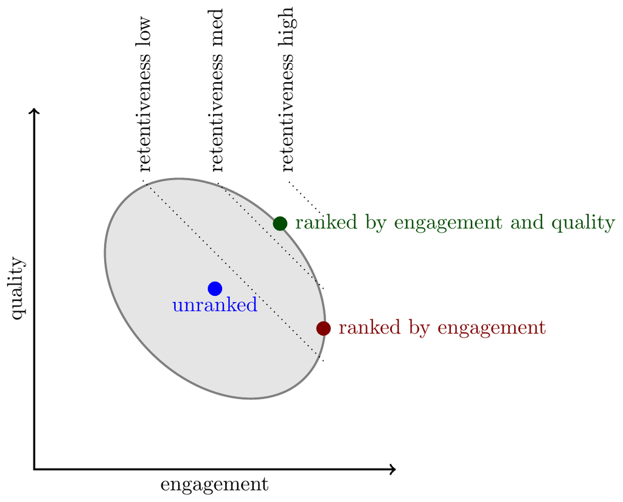

We illustrate the relationship with retention here with three lines representing different levels of retention, effectively these are indifference curves of a platform that is trying to maximize retention.

**Engagement and sensitivity.** Next consider “sensitive” attributes. We often see that more sensitive content has higher engagement rates, shown below as an upward-tilt to the Pareto frontier. In addition experiments that penalize sensitive content often have a negative effect on retention: this could be either due to a positive partial correlation between engagement and retentiveness, or a positive partial correlation between sensitivity and retentiveness. But in either case it seems that sensitive content does not have a strong negative effect on retention.

Despite these facts, most platforms still put substantial penalties on sensitive content, either directly or indirectly (as discussed above), and they pay a price in terms of both engagement and retention.

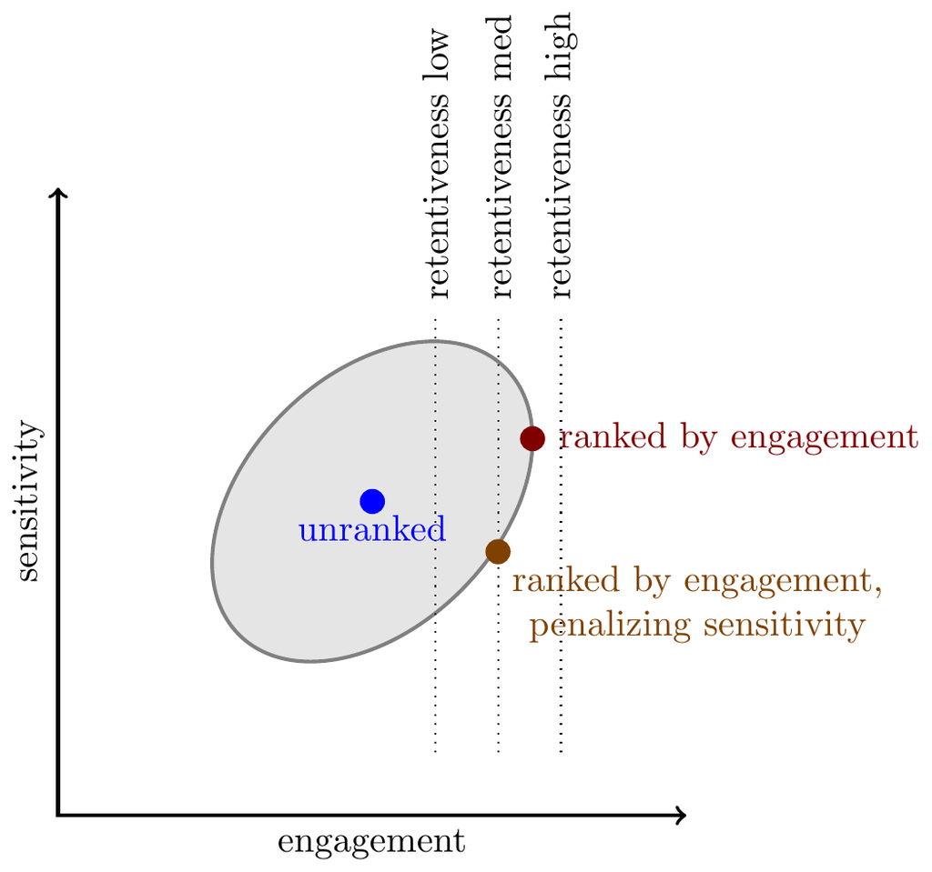

**Preference and sensitivity.** Finally consider a direct measure of user preference over content, e.g. asking users “is this informative?” or “would you like to see more like this?” In general user preference correlates relatively well with engagement, but it also offers incremental value for predicting retentiveness, in other words adding an additional term to the ranking function to predict user preference tends to increase retention.

However as discussed above, projects which collect survey questions are often focussed on the sensitivity of content rather than its retentiveness, and in that respect their findings are often mixed. Below we illustrate a case in which ranking by preference increases retentiveness but does not lower the amount of sensitive content (which platforms often desire). However platforms will offer try out many different wordings of survey questions, and each question will have somewhat different correlations.

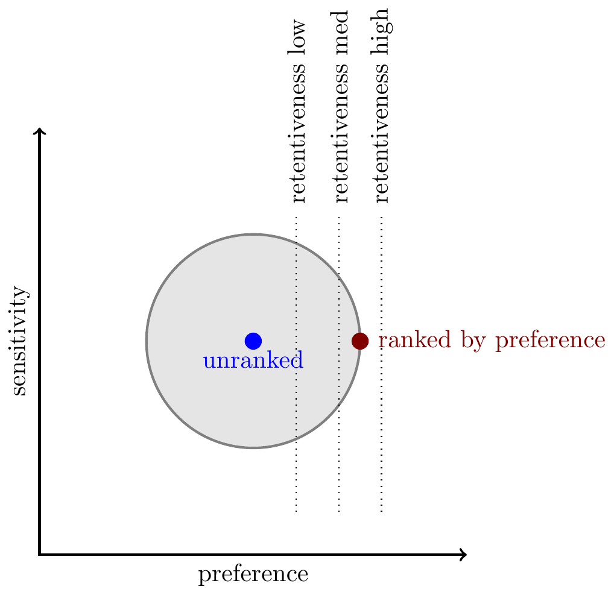

## Formal Observations

Here I describe a few formal properties of a model of ranking based on a joint-normal distribution of attributes. I have a longer writeup with proofs of these results which I hope to publish soon, I am happy to share a draft on request.

1. **The covariance between item attributes will determine a Pareto frontier among outcomes.** Suppose we know the joint distribution of attributes and we can choose a subset with share $p$ of the distribution (e.g. a fixed number of impressions given a pool of possible stories to show), and we want to calculate the average value of each attribute in the subset of content shown to the user. Then we can describe the Pareto frontier over subsets, i.e. the set of realized average outcomes, and it will be a function of the covariances among attributes over pieces of content. With 2 attributes the Pareto frontier will be an ellipse with shape exactly equal to an isoprobability curve from the joint density.

   The shape of the ellipse has a simple interpretation. If two attributes are positively correlated then the Pareto frontier will be *tight* meaning there is little tradeoff, i.e. we will have similar aggregate outcomes independent of the relative weights put on each outcome in ranking. If instead two attributes are negatively correlated then the Pareto frontier will be *loose* meaning outcomes will vary a lot with the relative weights used in ranking.

   Our assumption that the share $p$ is fixed is equivalent to assuming that any ranking rule will get the same number of impressions. This assumption obviously has some tension with *retentiveness* being an outcome variable: if some ranking rule has low retentiveness, then we would expect lower impressions. Accounting for this would make the Pareto frontier significantly more complicated to model, for simplicity we can interpret every attribute except retentiveness as a short-run outcome. Alternatively we could interpret them as relative instead of absolute outcomes, e.g. as engagement/impression or engagement/DAU.
2. **Improving a classifiers will stretch the Pareto frontier.** As a classifier gets better the average prediction will stay the same but the variance will increase, meaning the Pareto frontier will stretch out, and given a linear indifference curve we can derive the effect on outcomes.
3. **The joint distribution plus utility weights will determine ranking weights.** If we observe only some outcomes then we can calculate the conditional expectation for other outcomes. Typically we want to know retentiveness, and we can write the conditional expectation as follows:
   $$E[\text{retentiveness}|
   \text{engagement},\ldots,\text{user preference}].$$
   This expectation has a closed-form solution when the covariance matrix is joint normal. When we have just two signals, for example engagement and quality, we can write:

   $$\begin{aligned}
   E[r|e,q] &= \frac{1}{1-\gamma^2}(\rho_e-\gamma\rho_q)e +
   \frac{1}{1-\gamma^2}(\rho_q-\gamma\rho_e)q\\
   r &= \text{retentiveness}\\
   e &= \text{engagement (predicted)}\\
   q &= \text{quality (predicted)}\\
   \rho_{e} &= \text{covariance of engagement and retentiveness}\\
   \rho_{q} &= \text{covariance of quality and retentiveness}\\
   \gamma &= \text{covariance of engagement and quality}
   \end{aligned}$$

   Note that the slope of the iso-retentiveness line in $(e,q)$-space will be $-\frac{\rho_e-\gamma\rho_q}{\rho_q-\gamma\rho_e}$.
4. **Experiments which vary ranking weights tell us about covariances.** We can write findings from experiments as follows. First, suppose we find that retention is higher when ranked by engagement than when unranked, this can be written:

   $$\begin{aligned}
   \utt{E[r|e>e^*]}{ranked by}{engagement} &> \ut{E[r]}{unranked}
   \end{aligned}$$

   Here $e^*$ is chosen such that $P(e>e^*)=p$ for some $p$, representing the share of potential inventory that the user consumes. This implies that engagement must positively correlate with retentiveness, $\rho_e>0$.

   Next we can express that retention is higher when we put some weight $\beta$ on quality:

   $$\begin{aligned}
   \utt{E[r|e+\beta q>\kappa^*]}{ranked by}{engagement and quality} &> \utt{E[r|e>e^*]}{ranked by}{engagement}
   \end{aligned}$$

   Here $\kappa^*$ is chosen such that $P(e+\beta q > \kappa^*)=P(e>e^*)=p$. If $\beta$ is fairly small then we can infer that the iso-retentiveness line is downward-sloping, implying:
   $$\frac{\rho_e-\gamma\rho_q}{\rho_q-\gamma\rho_e}>0.$$

   This implies that both engagement and quality have the same sign. I don’t think they both can be negative, so they both must be positive:

   $$\begin{aligned}
   \rho_e - \gamma \rho_q &> 0 \\
   \rho_q - \gamma \rho_e &> 0.
   \end{aligned}$$
5. **I think it’s reasonable to treat preferences as locally linear.** To have a well-defined maximization problem (with an interior solution) we need either nonlinear preferences or a nonlinear Pareto frontier. It’s always easier to treat things as linear when you can, so a relevant question is which of these two is closer to linear? Internally companies often treat their preferences as nonlinear, e.g. setting specific goals and guardrails, but those are always flexible and often have justifications as incentive devices. Typical metric changes are small, only single-digit percentage points, over that range the Pareto frontier does show significant diminishing returns while (it seems to me) value to the company does not.

# Appendix: Literature

Milli, Pierson and Garg (2023) **Choosing the Right Weights: Balancing Value, Strategy, and Noise in Recommender Systems**

> “model in which two producers compete for the attention of one user. The recommender system ranks producers based on a linear combination of predictions of k behaviors. However, producers can strategically adapt their items to increase the probability of different user behaviors. User utility depends on being shown a high value producer, and a producer’s utility is the probability they are ranked highly minus their costs of strategic manipulation.”